# Examining the usage, citation, and diffusion patterns of bibliometric mapping software: A comparative study of three tools - ScienceDirect

## [Journal of Informetrics](https://www.sciencedirect.com/science/journal/17511577)

[Volume 12, Issue 2](https://www.sciencedirect.com/science/journal/17511577/12/2), May 2018, Pages 481-493

# Regular article Examining the usage, citation, and diffusion patterns of bibliometric mapping software: A comparative study of three tools

[XuelianPan<sup>a</sup>](https://www.sciencedirect.com/science/article/pii/S1751157717303292?casa_token=S69V9Jv2z0AAAAAA:W6Uns2b0dNANR9CLNFrcGx0ayYb7Bg8-T4wFIS24Z1jLB1r7x-H5qgs1fH4wywRCQ7ULjb4rH3M#!)[ErjiaYan<sup>b</sup>](https://www.sciencedirect.com/science/article/pii/S1751157717303292?casa_token=S69V9Jv2z0AAAAAA:W6Uns2b0dNANR9CLNFrcGx0ayYb7Bg8-T4wFIS24Z1jLB1r7x-H5qgs1fH4wywRCQ7ULjb4rH3M#!)[MingCui<sup>a</sup>](https://www.sciencedirect.com/science/article/pii/S1751157717303292?casa_token=S69V9Jv2z0AAAAAA:W6Uns2b0dNANR9CLNFrcGx0ayYb7Bg8-T4wFIS24Z1jLB1r7x-H5qgs1fH4wywRCQ7ULjb4rH3M#!)[WeinaHua<sup>a</sup>](https://www.sciencedirect.com/science/article/pii/S1751157717303292?casa_token=S69V9Jv2z0AAAAAA:W6Uns2b0dNANR9CLNFrcGx0ayYb7Bg8-T4wFIS24Z1jLB1r7x-H5qgs1fH4wywRCQ7ULjb4rH3M#!)

https://doi.org/10.1016/j.joi.2018.03.005[Get rights and content](https://s100.copyright.com/AppDispatchServlet?publisherName=ELS&contentID=S1751157717303292&orderBeanReset=true)

## Highlights

**•**

This paper conducts a content analysis of a sample of 481 English core journal articles using three bibliometric mapping software tools (CiteSpace, HistCite and VOSviewer) to reveal the predominant mention and citation practices.

**•**

We employ several diffusion indicators (e.g., diffusion breadth and speed on the article, journal and domain levels) to provide insight into the influence and [diffusion patterns](https://www.sciencedirect.com/topics/computer-science/diffusion-pattern) of the three software tools.

**•**

Researchers mention and cite the three software tools in diverse ways and some of them fail to provide a formal citation of the three software tools.

**•**

Among the three software tools, VOSviewer is more frequently used than CiteSpace and HistCite.

**•**

The three tools are adopted fastest and most frequently in [library and information science](https://www.sciencedirect.com/topics/computer-science/library-and-information-science) research, and they are then gradually adopted in other areas of study, initially at a lower diffusion speed but afterward at a rapidly growing rate.

## Abstract

This study investigates the use, citation and diffusion of three bibliometric mapping software tools (CiteSpace, HistCite and VOSviewer) in scientific papers. We first conduct a content analysis of a sample of 481 English core journal papers—i.e., papers from journals deemed central to their respective disciplines—in which at least one of these tools is mentioned. This allows us to understand the predominant mention and citation practices surrounding these tools. We then employ several diffusion indicators to gain insight into the diffusion patterns of the three software tools. Overall, we find that researchers mention and cite the tools in diverse ways, many of which fall short of a traditional formal citation. Our results further indicate a clear upward trend in the use of all three tools, though VOSviewer is more frequently used than CiteSpace or HistCite. We also find that these three software tools have seen the fastest and most widespread adoption in library and information science research, where the tools originated. They have since been gradually adopted in other areas of study, initially at a lower diffusion speed but afterward at a rapidly growing rate.

## Keywords

Software citation

Bibliometric mapping software

Knowledge diffusion

Bibliometrics

Scholarly communication

## 1. Introduction

Software is vital to scientific research: it assists scientists in identifying research questions, analyzing data, visualizing results and disseminating knowledge. Indeed, “just about every step of scientific work is affected by software” (Howison et al., 2015, p. 454). However, the academic role of software has long been undervalued or, worse yet, ignored in the current publication-driven scientific reward system. This issue is especially acute in recent years, as the variety of software available freely for academic use has increased tremendously (Hannay et al., 2009; Huang et al., 2013). As the value of data is increasingly recognized (Chao, 2011; Belter, 2014; Yu et al., 2015) and a significant amount of freely available software packages are used in the scientific community (Howison & Bullard, 2016; Thelwall & Kousha, 2016), some scholars argue that software too should be valued as an academic contribution (Hafer & Kirkpatrick, 2009; Piwowar, 2013). The U.S. National Science Foundation (NSF) has recognized software as a valid research output since 2013 (NSF, 2013), and the U.K. [Research Excellence](https://www.sciencedirect.com/topics/computer-science/research-excellence) Framework 2014 (Research Excellence Framework, 2013) lists it as a type of scholarly contribution. Nonetheless, many funding institutions, policy makers and administrators have not yet followed suit (Piwowar, 2013). It is therefore imperative to measure the impact of software, both to gain a better understanding of its value and to better reflect that value in research evaluations and scholarly communications.

Bibliometric indicators such as citation counts and journal impact factors are often used to evaluate the impact of papers (Cartes-Velásquez & Manterola Delgado, 2014), researchers (Fu & Ho, 2013; Havemann & Larsen, 2014; Jacob, Lehrl, & Henkel, 2007), and institutions (Abramo, D’Angelo, & Costa, 2011), because they make such evaluations less time-consuming and more objective (Thelwall & Kousha, 2016; Yu et al., 2015). The increasing significance of bibliometrics in research evaluation (Belter, 2014), along with “recent developments in computing and information services” (Ding et al., 2014, p. 1820), has led some scholars to suggest that bibliometric indicators can be used to measure the impact of a wider variety of knowledge entities, such as diseases, drugs, data sets, and software (Ding et al., 2013; Pan, Yan, Wang, & Hua, 2015; Urquhart & Dunn, 2013). However, recent studies on data citation have found that a significant number of data sets mentioned in the scientific literature were not formally cited (Mooney, 2011; Peters, Kraker, Lex, Gumpenberger, & Gorraiz, 2015). Likewise, our own previous study has found that more than 30% of mentioned software in articles published in *PLOS ONE* in 2014 received no formal citations (Pan, Yan, & Hua, 2016). Howison and Bullard (2016) have found that more than 50% of software mentions did not include references among the biology articles published in Web of Science (WoS) journals. Taken together, these prior studies evince a need to use alternative metrics in addition to citations when assessing the impact of software. Much research is yet needed before we can claim to have a comprehensive understanding of software’s impact on scientific research.

The study of [knowledge diffusion](https://www.sciencedirect.com/topics/social-sciences/knowledge-diffusion) through citations has become a standard topic in the field of [library and information science](https://www.sciencedirect.com/topics/computer-science/library-and-information-science) (LIS) (Liu & Rousseau, 2012). Researchers have explored the diffusion of scientific knowledge on multiple levels, ranging from that of the individual paper (Liu & Rousseau, 2012), to journals (Zhao & Wu, 2014), fields of study (Yan, 2016), institutions (Börner, Penumarthy, Meiss, & Ke, 2006), and countries (Lewison, Rippon, & Wooding, 2005). In these studies, citations are generally treated as an indication of knowledge flow from the cited entity to the citing one; specifically, the cited and citing entities are usually considered as the source and target of diffusion. A variety of knowledge-diffusion approaches have been proposed to measure the impact and [diffusion patterns](https://www.sciencedirect.com/topics/computer-science/diffusion-pattern) of such research outputs as papers (Liu & Rousseau, 2010), patents (Nomaler & Verspagen, 2008), handbooks (Milojević, Sugimoto, Larivière, Thelwall, & Ding, 2014), and databases (Yu et al., 2015). However, few studies have sought to apply these same approaches to software. In this article, we aim to go beyond an analysis of the citation of software in scientific literature. Using several quantitative diffusion indicators, we investigate software diffusion patterns as well as trends in academic impact.

In this article, we consider a piece of software to be diffused in the academic communication system when it is used in scientific articles. The software used and the paper using it are considered as the source and target of diffusion, respectively. In other words, the software influences the articles that make use of it. Based on the above hypothesis, we employ knowledge diffusion indicators to explore how bibliometric mapping software tools are used and diffused in scientific papers. Bibliometric mapping software tools, sometimes called science mapping software tools, are programs that have been developed for carrying out bibliometric mapping analysis (Cobo, López-Herrera, Herrera-Viedma, & Herrera, 2011). Bibliometric mapping, which aims at presenting the structural and dynamic aspects of scientific research, is an important research topic in the field of bibliometrics, which in turn is generally viewed as a branch of LIS (Börner, Chen, & Boyack, 2003; van Eck & Waltman, 2010). Many bibliometric mapping software tools have been created and used in the scholarly community (Cobo et al., 2011), but for this article, we select three widely used examples as the targets of our analysis: CiteSpace, VOSviewer, and HistCite. We conduct a content analysis of a sample of more than 800 English-language journal papers that cite or mention the selected software tools, thereby gaining insight into the software tools’ usage, citation, and diffusion patterns. The following research questions drive the investigation.

**1.**

How are the three bibliometric mapping software tools used and cited in scientific literature?

**2.**

What is the academic impact of the three software tools as measured by several diffusion indicators?

**3.**

What are the diffusion patterns of the three software tools?

The answers to these questions will provide a better understanding of the impact of software on science. Though framed as a case study, our analysis is considerably broader in its implications: it employs these popular tools as a research instrument to reveal the broader landscape of software use in bibliometric research. Using the tools as a relatable pivot point, this study is able to provide a context in which to understand usage and citation statistics. Though acknowledged as a vital complement to data-driven bibliometric research, such context has been lacking in prior studies of software use and impact. Moreover, this study treats software entities as knowledge units, explores the diffusion patterns of software entities in the academic communication system, and helps present a more complete picture of the communication patterns which surround diverse research outputs.

## 2. Literature review

### 2.1. Evaluations of the impact of software

Although indicators such as number of users, downloads, reviews, and subscribers might be used to assess the academic impact of software, such data are rarely available (Thelwall & Kousha, 2016). Moreover, some of these indicators cannot measure the impact of software very well (Howison, Deelman, McLennan, Da Silva, & Herbsleb, 2015) because, in many cases, they fail to accurately quantify user activity. Users can download [open source software](https://www.sciencedirect.com/topics/social-sciences/open-source-software) for free without leaving any information, download a piece of software and share it with friends and colleagues, or download a piece of software but never use it. Thelwall and Kousha (2016) have found a low correlation between the number of downloads and citations for given software packages.

The number of citations is often used to assess the impact of publications (Abramo et al., 2011; Cartes-Velásquez & Manterola Delgado, 2014) and data (Belter, 2014; Robinson-García, Jiménez-Contreras, & Torres-Salinas, 2015). It may seem that an indicator suitable for analyzing the impact of data would also be appropriate for assessing the impact of software. However, recent studies have found that many researchers fail to formally cite software in their scientific papers (Howison & Bullard, 2016; Li, Yan, & Feng, 2017; Pan et al., 2016). Thus, some scholars have suggested that researchers “must look beyond formal citations or reference lists” when they venture a bibliometric assessment of software’s impact (Howison & Bullard, 2016, p. 2151). Aware of these limitations, some scholars have used the number of mentions in full-text papers to assess the impact of software, based on an improved bootstrapping method (Pan et al., 2015). In addition, previous studies of the motivations for creating and sharing research software have suggested that “increased citation would drive increased software development and sharing” (Howison & Herbsleb, 2011; Niemeyer, Smith, & Katz, 2016, p. 1). These studies have prompted fruitful discussions about prospective changes in software citation practices. Guiding principles (Smith, Katz, & Niemeyer, 2016) and tools (Piwowar & Priem, 2016; Soito & Hwang, 2016) have been developed to help authors cite software appropriately.

### 2.2. Knowledge diffusion through citations

As one cornerstone of the development of science, [knowledge diffusion](https://www.sciencedirect.com/topics/social-sciences/knowledge-diffusion) has attracted substantial attention from researchers in various areas (Faber Frandsen, Rousseau, & Rowlands, 2006; Milojević et al., 2014; Rowlands, 2002; Wu, Yan, & Hill, 2017). In the field of [library and information science](https://www.sciencedirect.com/topics/computer-science/library-and-information-science), many researchers (Barnett, Fink, & Debus, 1989; Leeuwen & Tijssen, 2000; Liu & Rousseau, 2012; Yan, 2016) have also expressed interest in the diffusion of knowledge through citations, as well as the patterns underlying such diffusion. The research is often undergirded by the *diffusion of innovations* theory, which seeks to explain how, why, and at what rate new ideas and technologies spread through cultures.

Rogers has defined diffusion as “the process by which an innovation is communicated through certain channels over time among the members of a social system” (Rogers, 2003, p. 11). The adoption of an innovation, he proposes, follows an S-shaped curve when plotted over a length of time. Liu and Rousseau (2012) have suggested that the process of idea diffusion through scholarly citations resembles that of [innovation diffusion](https://www.sciencedirect.com/topics/computer-science/innovation-diffusion) through a social system. In their study of the diffusion of a Nobel Prize-winning article through citations, they found an S-shaped [diffusion pattern](https://www.sciencedirect.com/topics/computer-science/diffusion-pattern) similar to that described by Rogers.

Scholars have analyzed the diffusion of knowledge through citations on various levels. For instance, a study of journal-level knowledge flows has found that some library and information science journals receive citation flows from communication science journals (Borgman & Rice, 1992). At the disciplinary level, Van Leeuwen and Tijssen (2000) found that papers in one discipline are more likely to cite papers in the same discipline or nearby disciplines. Meanwhile, Rinia, Van Leeuwen, Bruins, Van Vuren, & Van Raan (2001) found that *intra*disciplinary citations of research tended to occur sooner than *inter*disciplinary ones. More recently, Rousseau and colleagues (Faber Frandsen et al., 2006; Liu & Rousseau, 2010) have proposed several quantitative diffusion indicators, such as journal diffusion factor and field diffusion intensity, to describe the diffusion characteristics of research production and measure the impact of research. In addition to studies on the diffusion of knowledge through paper citations, Yu et al. (2015) have taken databases as a type of knowledge entity and traced their use and diffusion. Despite these prior efforts, examination of the diffusion of scientific software is largely lacking. It is the goal of this study to reveal the diffusion patterns of bibliometric mapping software, using three widely deployed software tools as examples.

## 3. Methods

### 3.1. Selection of bibliometric mapping software tools

We first selected 10 bibliometric mapping software tools—Bibexcel, CitNetExplorer, CiteSpace, CoPalRed, HistCite, Network Workbench Tool, SciMAT, Sci<sup>2</sup> Tool, VantagePoint, and VOSviewer—as candidates for further analysis based on three sources: a review paper on bibliometric mapping software tools (Cobo et al., 2011), an overview of bibliometric network visualization (van Eck & Waltman, 2014) and a recent review paper on bibliometric mapping (Chen, 2017). We then searched Web of Science for English-language journal papers, published before January 2018, which mentioned these tools in the title, keyword, and abstract fields. The search was limited to Science Citation Index Expanded (SCI), Social Sciences Citation Index (SSCI) and Arts & Humanities Citation Index (A&HCI). (For brevity’s sake, the journals included in these indices are referred to as *English core journals* throughout the remainder of this article.) Document types were limited to articles and review articles. Table 1 shows the selected software tools, search terms, and number of papers containing our search terms in the topic field. We chose CiteSpace, HistCite and VOSviewer, the three tools most frequently mentioned in the topic field, as the targets of this study.

Table 1. Ten bibliometric mapping software tools and the number of WoS papers mentioning these tools in the topic field.

| Software tool | Search terms | #Papers |
| --- | --- | --- |
| Bibexcel | Bibexcel or “Bib excel” | 19 |
| CitNetExplorer | CitNetExplorer | 5 |
| CiteSpace | CiteSpace or “Cite Space” | 78 |
| CoPalRed | CoPalRed | 3 |
| HistCite | HistCite or “Hist Cite” | 30 |
| Network Workbench Tool | “Network Workbench Tool” or “NWB Tool” or “Network Workbench (NWB)” | 2 |
| SciMAT | SciMAT or “Sci MAT” | 5 |
| Sci<sup>2</sup> Tool | “Sci2 tool” or “Science of Science (Sci2)” or “Science of Science tool” or “Sci2 (Science of Science)” | 3 |
| VantagePoint | VantagePoint | 9 |
| VOSviewer | VOSviewer or “VOS viewer” | 70 |

CiteSpace ([http://cluster.cis.drexel.edu/∼cchen/citespace/](http://cluster.cis.drexel.edu/~cchen/citespace/); Chen, 2004, Chen, 2006), a freely available software tool for analyzing, detecting and visualizing trends and patterns in scientific literature, was developed by Chaomei Chen in 2004 at Drexel University (USA). It was last updated in October 27, 2017 (as of Jan 2018). The official CiteSpace website provides a selection of related papers and books, a manual, and tutorial links.

VOSviewer ([http://www.VOSviewer.com/](http://www.vosviewer.com/); van Eck & Waltman, 2010) was developed by Nees Jan van Eck and Ludo Waltman in 2010 at Leiden University (The Netherlands). It is a freely available software tool for constructing and viewing bibliometric maps and was last updated in October 23, 2017 (as of Jan 2018). Its official website includes learning materials (papers, a book chapter, a manual, and an introductory video) for those interested in using VOSviewer. The website also contains a list of technical publications about VOSviewer and an extensive bibliography of the tool’s applications in research.

HistCite (http://www.garfield.library.upenn.edu/histcomp/index.html; Garfield, Pudovkin, & Istomin, 2003) was developed by Eugene Garfield in 2001 and officially launched in 2007 (Herther, 2007). Its author describes it as “a software system which generates chronological maps of bibliographic collections resulting from subject, author, institutional or source journal searches of the ISI Web of Science” (Garfield, 2009 p. 173). Formerly a commercial software tool, it can now be freely downloaded from [https://support.clarivate.com/WebOfScience/s/article/HistCite-No-longer-in-act ive-development-or-officially-supported](https://support.clarivate.com/WebOfScience/s/article/HistCite-No-longer-in-act%20ive-development-or-officially-supported).

### 3.2. Data collection

We separately downloaded the full texts and bibliographies of the WoS papers that mentioned the three bibliometric mapping software tools in the title, keyword, or abstract fields. In this way, we obtained a total of 178 full-text English-language papers: 78 mentioning CiteSpace, 70 VOSviewer, and 30 HistCite. To add more papers to our data set, we first identified the key technical papers about each of the three software tools, then collected the WoS papers that cite these papers. It’s worth noting that these papers, too, were limited to SCIE, SSCI and A&HCI’s journal articles and review articles, written in English, and published between 1900 and 2017, inclusive. Table 2 presents the major technical papers on the three software tools and the number of papers that cite them. In all, we obtained 398 papers that cited the CiteSpace technical papers, 268 papers for VOSviewer, and 143 papers for HistCite, once duplicates and the technical papers themselves were subtracted from the count. A total of 809 papers were collected in this way.

Table 2. Key technical papers on CiteSpace, HistCite and VOSviewer.

[output not shown]

*Note:* #Papers indicates the number of WoS papers that cite the technical paper.

Among the 178 papers that mentioned the three bibliometric mapping software tools in the title, keyword, or abstract fields, 170 actually used the software tools. These were labeled simply as the *topic group* and constituted the data set for studying the mention and citation of the three software tools. Of the 809 papers citing the technical papers on CiteSpace, HistCite and VOSviewer, 432 which actually used the software tools were identified. This suggests that about 47% of papers that cite software technical papers do not use the software. A total of 481 journal papers using the three bibliometric mapping software tools were gathered from the above two data sets after removing duplicates. This merged data set was used to investigate the academic impact and [diffusion patterns](https://www.sciencedirect.com/topics/computer-science/diffusion-pattern) of the three software tools.

### 3.3. Coding scheme for mentions and citations of software in full-text papers

A content analysis was conducted to investigate how the three bibliometric mapping software tools are used and cited in scientific papers. The coding scheme, shown in Table 3, was created based on the work of Howison & Bullard (2016). It should be noted that this study focused on explicit uses of software rather than mere mentions—that is, only papers that actually used the software tools were selected. For example, from the paper “Emerging research fronts in science and technology: patterns of new knowledge development” in *Scientometrics*, we identified a sentence that mentioned HistCite:

> Recently, many researchers have focused on the visualization of these fields, developing tools such as crossmapping and DIVA (Morris and Moore, 2000), HistCite (Garfield, 1988; Garfield et al., 2003), and Pathfinder (White, 2003), and methods for graphing large-scale maps of science (Small, 1997).

Table 3. Coding scheme for mentions and citations of software and Cohen’s kappa regarding reliability testing for each category.

| Category | Description | Cohen’s kappa |
| --- | --- | --- |
| PaperID | ID of a particular paper mentioning the software. | 1 |
| Software name | The name of the software. | 1 |
| Position | Location mentioning the software, including Title, Keywords, Abstract, Body, Acknowledgement, Supplement, and Other. | 0.865 |
| Used | Indicates whether the software is used in this research. | 0.911 |
| Version number | Particular version of the software used. | 0.902 |
| URL | Web address of the software. | 0.889 |
| Citation | Denotes whether this paper provides a formal citation of the software in the reference list. | 0.865 |
| Reference entry | Denotes an entry linked to the software in a reference list. | 0.734 |
| Reference publication | Denotes citation of a particular publication. | 0.932 |
| Reference manual | Denotes citation of a specific user guide or manual. | 1 |
| Reference website | Denotes citation of a URL or project name. | 0.850 |

This was coded as follows:

> “HistCite” was mentioned rather than used by the authors because we found that the authors did not employ HistCite to process the data or get the results by reading this paper.

Two coders were trained before they began to separately code the papers. A random sample of 30 papers was coded to measure inter-coder reliability as assessed by Cohen’s kappa statistics. The kappa coefficient for each category was calculated using ReCal2 (http://dfreelon.org/utils/recalfront/recal2/; Freelon, 2010) and is reported in Table 3. The coefficients range from 0.734 to 1, suggesting good agreement (Altman, 1990).

### 3.4. Indicators for measuring the diffusion of software

In this study, we introduce several indicators to measure the impact and diffusion of software through use, based on the diffusion indicators proposed by Rousseau (2005) and Liu and Rousseau (2010). The first type of indicator is *diffusion breadth*, which is subdivided into the following three indicators:

**•**

paper diffusion breadth: the number of papers using the software;

**•**

journal diffusion breadth: the number of journals in which the papers using the software are published; and

**•**

domain diffusion breadth: the number of domains to which the papers using the software belong.

The second class of indicator is *diffusion time*, defined as the number of years since the software was created. For example, the diffusion time of CiteSpace equals 1 for a paper published in 2004, when CiteSpace was created.

The third category, *diffusion speed*, includes a further three indicators:

**•**

average diffusion speed over papers: the total number of papers using a software tool divided by the number of years since it was created—in other words, paper diffusion breadth divided by diffusion time;

**•**

diffusion speed over journals and diffusion speed over domains: the total number of journals publishing papers using a software tool and the number of domains with papers using a software tool, each divided by diffusion time.

We investigate the diffusion breadth and diffusion speed of CiteSpace, HistCite and VOSviewer within the WoS papers using the indicators described above. It is worth noting that every journal indexed in WoS Core Collection was assigned to one or more research areas. In this article, the research areas of a journal are taken as the domains of its papers.

## 4. Results

### 4.1. Characteristics of mentions and citations of the bibliometric mapping software tools

We first focus on examining whether users provide version and website information—useful means for a reader to learn about the software tools—in their articles. In the topic group, 51 (30% of 170) and 40 (24% of 170) papers, respectively, provided version and website information in the title, abstract, or body text. However, 95 (56% of 170) papers in the topic group provided no further information than the name of the bibliometric mapping software tool in the article body (see Table 4). Moreover, 41% papers using CiteSpace provided version information, a higher percentage than that observed for HistCite or VOSviewer.

Table 4. Bibliometric mapping software tool mentions in the topic group.

| Software tool | #Papers | #Version | #Website | #Name Only |
| --- | --- | --- | --- | --- |
| CiteSpace | 73 | 30 (41% of 73) | 12 (16% of 73) | 36 (49% of 73) |
| HistCite | 28 | 6 (21% of 28) | 8 (29% of 28) | 15 (54% of 28) |
| VOSviewer | 69 | 15 (22% of 69) | 20 (29% of 69) | 44 (64% of 69) |
| Total | 170 | 51 (30% of 170) | 40 (24% of 170) | 95 (56% of 170) |

*Note:* #Papers indicates the number of papers using the software tool in the topic group; #Version and #Website, respectively, indicate the number of papers providing version and website information; #Name Only indicates the number of papers that provided no further information than the name of the software tool.

Table 5. Citation rate of the bibliometric mapping software tools by year.

[output not shown]

*Note:* P indicates the number of papers using CiteSpace, VOSviewer, or HistCite; C indicates the number of papers citing CiteSpace, VOSviewer, or HistCite; R indicates citation rate (the ratio of P to C).

We then examine the cited references related to the three bibliometric mapping software tools. Among the 57 papers formally citing CiteSpace in the reference list, 55 (96.49%) cite a related publication, 7 (12.28%) cite a website, and none cite a user manual. This shows that researchers are more likely to cite related publications than other material (e.g., manual, website, and project name) when they document their use of CiteSpace. Similar results are found among VOSviewer citations: of the 54 papers formally citing VOSviewer, 48 (88.89%) cite a publication, 3 cite a website and 4 cite a user manual. Among the 19 papers that included a formal citation of HistCite, all the papers cite a related publication; none cite websites or user manuals. Within the topic group, technical papers CitPaper2, HisPaper4, and VOSPaper1 are the most frequently cited publications for the corresponding software tools, with 42, 4, and 39 citations, respectively.

### 4.2. Diffusion of the bibliometric mapping software tools

In this section, we investigate the diffusion of the three bibliometric mapping software tools within our data set of 481 scientific papers. Fig. 1 displays the paper diffusion breadth of CiteSpace, HistCite and VOSviewer from 2002 to 2017, which shows that the numbers of papers using each tool have greatly increased. Specifically, the paper diffusion breadth of VOSviewer, which was developed later than CiteSpace and HistCite, has increased from 2 in 2010–247 in 2017. The paper diffusion breadth of VOSviewer has remained higher than those of the other two software tools since 2015. While HistCite was created earlier than CiteSpace and VOSviewer, the paper diffusion breadth of HistCite is narrower than that of the above two software tools in most recent years, possibly due to the lower update frequency of HistCite.

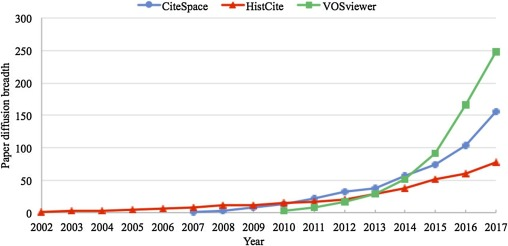

Fig. 1. Paper diffusion breadth of the three bibliometric mapping software tools.

We also explore the journal and domain diffusion breadth of the three bibliometric mapping software tools. Both journal and domain diffusion breadth for VOSviewer have increased markedly over the past seven years: journal breadth has increased from 2 in 2010–114 in 2017; domain breadth has increased from 1 in 2010–50 in 2017. Meanwhile, the journal and domain breadth of CiteSpace have increased from 1 to 91 and 1–45, respectively, while the same two indicators for HistCite have increased from 1 to 46 and 1–27.

As illustrated in Fig. 2, we find that the diffusion speed over papers is increasing steadily over all for each of the three tools. Initially (2007–2008), the diffusion speed over papers of HistCite is faster than that of CiteSpace, but this relationship reverses after 2009. In the most recent period (2010–2017), the diffusion speed over papers of VOSviewer is faster than those of the other two software tools.

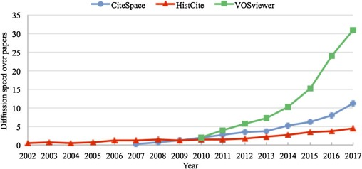

Fig. 2. Diffusion speed over papers of the three bibliometric mapping software tools.

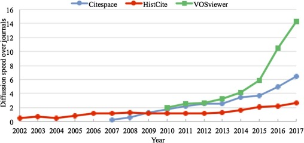

Fig. 3. Diffusion speed over journals of the three bibliometric mapping software tools.

Finally, Fig. 4 displays the diffusion speeds on the domain level. The curve of VOSviewer diffusion speed over domains has an S-shaped pattern: VOSviewer diffuses slowly in the early stage, then more rapidly up to an [inflection point](https://www.sciencedirect.com/topics/computer-science/inflection-point). The diffusion then slows once more in the most recent period. In contrast, the domain diffusion speed of CiteSpace shows a continuous increasing trend through 2017. As with the paper- and journal-level metrics, the diffusion speed over domains of HistCite is slower than those of CiteSpace and VOSviewer between 2010 and 2017.

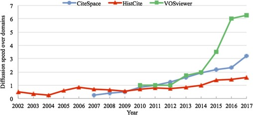

Fig. 4. Diffusion speed over domains of the three bibliometric mapping software tools.

Table 6. Disciplines with five or more papers using the software tools.

| Research field | #Papers | Year | Research field | #Papers | Year |
| --- | --- | --- | --- | --- | --- |
| Information Science & Library Science | 215 | 2002 | Cell Biology | 9 | 2014 |
| Computer Science | 213 | 2002 | Social Sciences – Other Topics | 8 | 2011 |
| Business & Economics | 50 | 2010 | Neurosciences & Neurology | 8 | 2014 |
| Science & Technology – Other Topics | 44 | 2005 | Pharmacology & Pharmacy | 8 | 2014 |
| Environmental Sciences & Ecology | 29 | 2006 | Psychology | 7 | 2008 |
| Engineering | 24 | 2009 | Physics | 7 | 2014 |
| Public, Environmental & Occupational Health | 14 | 2005 | Biotechnology & Applied Microbiology | 6 | 2012 |
| Operations Research & Management Science | 12 | 2010 | Research & Experimental Medicine | 6 | 2012 |
| Energy & Fuels | 10 | 2013 | Chemistry | 6 | 2013 |
| General & Internal Medicine | 10 | 2014 | Materials Science | 6 | 2013 |
| Public Administration | 9 | 2011 | Geography | 5 | 2006 |
| Education & Educational Research | 9 | 2013 | Nursing | 5 | 2016 |

*Note:* #Papers indicates the number of papers using CiteSpace, HistCite or VOSviewer belonging to a particular research field; Year indicates the publication year of the first paper using CiteSpace, HistCite or VOSviewer which belongs to a particular research field.

Table A1 (Appendix A) presents the research fields to which scientific papers using the three bibliometric mapping software tools belonged in each year. We find that HistCite was first used by a paper published in *Proceedings of the 65th ASIST Annual Meeting*, a publication which belongs to the LIS, Computer Science, and Social Issues domains. HistCite was next used in computer science in 2003. Similarly, CiteSpace was first used in the field of LIS in 2007, then diffused to computer science in 2008. We also find that VOSviewer was first used in the field of LIS (2010), then in Public Administration (2011) and Business & Economics (2012). From 2010 on, CiteSpace, HistCite and VOSviewer are used in more than six fields per year. In 2017, the three software tools were collectively used in more than 45 fields.

## 5. Discussion

We found evidence of an overall lack of consistency in CiteSpace, HistCite and VOSviewer mention and citation practices. Information about the software tools used in research is clearly helpful for readers who may wish to seek out the software for their own use. Nonetheless, a considerable proportion of article authors did not provide sufficient information related to their use of the software tools. Even among those scholars who both used and mentioned the software tools, many did not include a formal citation. Although citable items such as publications and a user manual are available on the CiteSpace website, 22% of WoS papers lacked a formal citation of CiteSpace in the reference list. The uncitedness of VOSviewer (0.22) is similar to that of CiteSpace, but less than that of HistCite (0.32). Among those scholars who did include a formal citation, a variety of practices may be observed: some preferred to cite publications related to the software tools, while others cited user manuals, websites, or even the name of the software development project. This, again, is presumably due to a lack of normalized software citation standards. Of these various citation forms, however, the highest proportion of papers favored the citation of publications related to the software tools. This corroborates earlier findings suggesting that most scholars tend to cite software publications. In particular, our results align with a previous study on the data citation practices of social-science researchers (Mooney, 2011).

CiteSpace, HistCite and VOSviewer are software tools for bibliometric mapping—an important research topic in the field of bibliometrics (Börner et al., 2003; Cobo et al., 2011; Van Eck & Waltman, 2010). There was clear evidence that CiteSpace, HistCite and VOSviewer are most frequently used in the field of LIS. The widespread use of the three bibliometric mapping software tools in LIS research accords with the notion that a piece of software is more likely to be frequently used in its original field. We also find that all three software tools were first used in the field of LIS, then in other fields such as computer science and public administration. This [diffusion process](https://www.sciencedirect.com/topics/computer-science/diffusion-process) demonstrates that software is likely to be used first in its original field, then diffuse outward to closely related disciplines before finding use in a more diverse array of fields. These findings are similar to those found in diffusion studies on publications (Rinia et al., 2001; Van Leeuwen & Tijssen, 2000). The results suggest that the process of software diffusion through use is similar to that of [knowledge diffusion](https://www.sciencedirect.com/topics/social-sciences/knowledge-diffusion) through citations in the academic communication system.

## 6. Conclusion

In this article, we investigate the use, citation, and diffusion of CiteSpace, HistCite, and VOSviewer in scientific literature. We first collected English journal papers that indicated potential use of the three software tools, then manually selected papers which actually used the tools as our analysis targets. Content analysis was used to identify salient characteristics of CiteSpace, HistCite and VOSviewer mentions and citations in scientific papers. Several diffusion indicators were proposed to measure the impact and diffusion of the three software tools through the corpus of scientific papers. We also explored patterns of software adoption and usage across research fields and over time. The most important contribution of this work is, we believe, in the methodology proposed for measuring the impact and diffusion of software. This study is an effort to acknowledge the place of software tools in the ecology of scholarly communication, thereby obtaining a more complete view of knowledge production and diffusion.

Researchers, we found, mention and cite the three software tools in a variety of ways. Although providing detailed information helps readers to locate the software tools, some researchers mentioned the tools only by name. Several citable items are provided on the CiteSpace and VOSviewer websites, yet a considerable number of papers made no formal citation. Moreover, the citation rates of the three software tools have continued to decrease over the most recent four years (2014–2017). These findings suggest, on the one hand, that the situation of software citation practices is not improving; on the other hand, they provide evidence that a scientific idea may become disassociated from the publication in which it was first put forward as it diffuses further (Borgman, 1989).

An important limitation of this study lies in its paper selection criteria. We focus on SCI/SSCI/A&HCI journal papers which either cite the software tools or mention them in their title, abstract, or keywords. Thus, we necessarily exclude some publications which use the software tools without citing them or mentioning them in these fields. The absence of these publications from our dataset likely leads to an underestimation of the impact of the software tools. For instance, we find that there are a total of 474 publications using VOSviewer in the period of 2010–2017 according to a list provided by the tool’s developers (www.vosviewer.com/publications), but the methods used in this study identified only 247 SCI/SSCI/A&HCI journal papers using VOSviewer for inclusion in our analysis. Moreover, the selection of the SCI/SSCI/A&HCI journal papers probably leads to a higher observed citation rate, since a recent study has found that articles mentioning software in the title, keywords and abstract are more likely to formally cite the software than are those mentioning software in the article body (Pan et al., 2017).

Despite the limitations of this study, this article takes CiteSpace, HistCite and VOSviewer as examples to illustrate trends in software usage, citation, and diffusion in the academic communication system. Our findings provided further evidence that software is important to research, but that the practices of software mention and citation are still inconsistent. Greater consistency in this respect will lay a foundation for improving software citation practices overall and will contribute to a more effective use of scientific software.

## Author’s contribution

Xuelian Pan: Conceived and designed the analysis.

## Acknowledgments

This work was funded by the National Natural Science Foundation of China (Grant No. 71704077). We would like to thank Dr. Ludo Waltman and Dr. Chaomei Chen for many helpful comments and valuable feedback on previous versions of this paper. Also, we are grateful to the reviewers for their helpful suggestions.

## Appendix A.

Table A1. Disciplines to which papers using the three bibliometric mapping software tools belong, organized by year of publication.

| Research field | 2002 | 2003 | 2004 | 2005 | 2006 | 2007 | 2008 | 2009 | 2010 | 2011 | 2012 | 2013 | 2014 | 2015 | 2016 | 2017 | Sum |
| --- | --- | --- | --- | --- | --- | --- | --- | --- | --- | --- | --- | --- | --- | --- | --- | --- | --- |
| Agriculture |  |  |  |  |  |  |  |  |  |  |  |  |  |  | * | * | 3 |
| Architecture |  |  |  |  |  |  |  |  |  |  |  |  |  | * |  |  | 1 |
| Biochemistry & Molecular Biology |  |  |  |  |  |  |  |  |  |  |  |  |  | * | * | * | 3 |
| Biodiversity & Conservation |  |  |  |  |  |  |  |  | * |  |  |  |  |  | * |  | 2 |
| Biophysics |  |  |  |  |  |  |  |  |  |  |  |  |  |  |  | * | 1 |
| Biotechnology & Applied Microbiology |  |  |  |  |  |  |  |  |  |  | * |  | * |  | * | * | 6 |
| Business & Economics |  |  |  |  |  |  |  |  | * |  | * | * | * | * | * | * | 50 |
| Cell Biology |  |  |  |  |  |  |  |  |  |  |  |  | * | * |  | * | 9 |
| Chemistry |  |  |  |  |  |  |  |  |  |  |  | * |  | * | * | * | 6 |
| Computer Science | * | * |  |  | * |  | * | * | * | * | * | * | * | * | * | * | 213 |
| Construction & Building Technology |  |  |  |  |  |  |  |  |  |  |  |  |  |  |  | * | 2 |
| Cultural Studies |  |  |  |  |  |  |  |  |  |  |  |  |  |  | * |  | 1 |
| Developmental Biology |  |  |  |  |  |  |  |  |  |  |  |  |  |  | * | * | 2 |
| Education & Educational Research |  |  |  |  |  |  |  |  |  |  |  | * | * |  | * | * | 9 |
| Energy & Fuels |  |  |  |  |  |  |  |  |  |  |  | * | * | * | * | * | 10 |
| Engineering |  |  |  |  |  |  |  | * | * |  |  |  | * | * | * | * | 24 |
| Environmental Sciences & Ecology |  |  |  |  | * | * |  |  | * |  |  | * | * | * | * | * | 29 |
| Evolutionary Biology |  |  |  |  |  |  |  |  |  |  |  |  |  |  |  | * | 1 |
| Food Science & Technology |  |  |  |  |  |  |  |  |  |  |  |  |  |  | * |  | 1 |
| Forestry |  |  |  |  |  |  |  |  |  | * |  |  |  |  |  |  | 1 |
| General & Internal Medicine |  |  |  |  |  |  |  |  |  |  |  |  | * | * | * | * | 10 |
| Geography |  |  |  |  | * |  |  |  |  |  |  | * | * | * | * |  | 5 |
| Geology |  |  |  |  |  |  |  |  |  |  |  |  |  |  | * |  | 1 |
| Health Care Sciences & Services |  |  |  |  |  |  |  |  |  |  |  |  | * |  | * | * | 3 |
| Immunology |  |  |  |  |  |  |  |  |  |  |  |  |  |  | * | * | 3 |
| Information Science & Library Science | * |  |  |  | * | * | * | * | * | * | * | * | * | * | * | * | 215 |
| Linguistics |  |  |  |  |  |  |  |  |  |  |  |  |  | * |  | * | 2 |
| Marine & Freshwater Biology |  |  |  |  |  |  |  |  |  | * |  |  |  |  | * |  | 2 |
| Materials Science |  |  |  |  |  |  |  |  |  |  |  | * |  |  | * | * | 6 |
| Mathematical & Computational Biology |  |  |  |  |  |  |  |  |  |  |  |  | * |  |  |  | 1 |
| Mathematics |  |  |  |  |  |  |  |  |  |  |  |  |  | * | * |  | 2 |
| Mechanics |  |  |  |  |  |  |  |  |  |  |  |  |  |  |  | * | 1 |
| Medical Informatics |  |  |  |  |  |  |  |  |  |  |  | * |  |  |  | * | 3 |
| Meteorology & Atmospheric Sciences |  |  |  |  |  |  |  |  |  |  |  |  |  |  | * | * | 2 |
| Microbiology |  |  |  |  |  |  |  |  |  |  |  |  |  |  | * |  | 2 |
| Neurosciences & Neurology |  |  |  |  |  |  |  |  |  |  |  |  | * | * |  | * | 8 |
| Nursing |  |  |  |  |  |  |  |  |  |  |  |  |  |  | * | * | 5 |
| Obstetrics & Gynecology |  |  |  |  |  |  |  |  |  |  |  |  |  | * |  |  | 1 |
| Oceanography |  |  |  |  |  |  |  |  |  | * |  |  |  |  |  |  | 1 |
| Oncology |  |  |  |  |  |  |  |  |  |  |  | * |  |  |  | * | 3 |
| Operations Research & Management Science |  |  |  |  |  |  |  |  | * |  | * |  | * | * | * | * | 12 |
| Ophthalmology |  |  |  |  |  |  |  |  |  |  |  |  |  |  | * |  | 1 |
| Pediatrics |  |  |  |  |  |  |  |  |  |  |  |  |  | * |  | * | 2 |
| Pharmacology & Pharmacy |  |  |  |  |  |  |  |  |  |  |  |  | * |  | * | * | 8 |
| Philosophy |  |  |  |  |  |  |  |  |  | * |  |  |  |  | * |  | 2 |
| Physical Geography |  |  |  |  |  |  |  |  |  |  |  |  | * |  | * |  | 3 |
| Physics |  |  |  |  |  |  |  |  |  |  |  |  | * | * | * | * | 7 |
| Physiology |  |  |  |  |  |  |  |  |  |  |  |  |  |  | * | * | 2 |
| Plant Sciences |  |  |  |  |  |  |  |  |  |  |  |  |  |  | * | * | 2 |
| Psychiatry |  |  |  |  |  |  |  |  |  |  |  |  |  | * |  |  | 2 |
| Psychology |  |  |  |  |  |  | * |  |  |  |  |  |  | * | * | * | 7 |
| Public Administration |  |  |  |  |  |  |  |  |  | * | * |  | * | * | * | * | 9 |
| Public, Environmental & Occupational Health |  |  |  | * |  |  |  |  |  |  |  |  |  | * | * | * | 14 |
| Remote Sensing |  |  |  |  |  |  |  |  |  |  |  |  |  |  | * | * | 3 |
| Research & Experimental Medicine |  |  |  |  |  |  |  |  |  |  | * |  | * | * | * | * | 6 |
| Science & Technology – Other Topics |  |  |  | * |  |  | * |  |  | * |  | * | * | * | * | * | 44 |
| Social Issues | * |  |  |  |  |  |  |  |  |  |  |  |  |  |  |  | 1 |
| Social Sciences – Other Topics |  |  |  |  |  |  |  |  |  | * | * |  |  | * | * | * | 8 |
| Sport Sciences |  |  |  |  |  |  |  |  |  |  |  | * |  |  |  |  | 2 |
| Substance Abuse |  |  |  |  |  |  |  |  |  |  |  |  |  |  |  | * | 1 |
| Surgery |  |  |  |  |  |  |  |  |  |  |  |  |  |  |  | * | 1 |
| Telecommunications |  |  |  |  |  |  |  |  |  |  |  |  |  | * |  |  | 1 |
| Thermodynamics |  |  |  |  |  |  |  |  |  |  |  |  |  |  |  | * | 1 |
| Toxicology |  |  |  |  |  |  |  |  |  |  |  |  |  |  |  | * | 1 |
| Transplantation |  |  |  |  |  |  |  |  |  |  |  |  |  |  |  | * | 1 |
| Urban Studies |  |  |  |  |  |  |  |  |  |  |  |  |  | * |  |  | 1 |
| Urology & Nephrology |  |  |  |  |  |  |  |  |  |  |  |  |  |  | * |  | 1 |
| Water Resources |  |  |  |  |  |  |  |  |  |  |  |  |  |  | * |  | 2 |
| Zoology |  |  |  |  |  |  |  |  |  |  |  |  |  |  | * | * | 2 |
| P | 1 | 1 | 0 | 2 | 3 | 2 | 6 | 5 | 10 | 17 | 22 | 27 | 49 | 73 | 114 | 149 | 481 |
| D | 3 | 1 | 0 | 2 | 4 | 2 | 4 | 3 | 7 | 9 | 8 | 13 | 21 | 28 | 44 | 46 | 69 |

*Note:* * indicates that one or more papers belong to a particular discipline were published in a particular year; The “P” row illustrates the number of papers using the software tools per publication year; The “D” row shows the number of disciplines per publication year; The “Sum” column shows the number of papers using the software tools per domain.

## References

**Abramo et al., 2011**

G. Abramo, C.A. D’Angelo, F. Di Costa

**National research assessment exercises: A comparison of peer review and bibliometrics rankings**

Scientometrics, 89 (3) (2011), pp. 929-941

[CrossRef](https://doi.org/10.1007/s11192-011-0459-x)[View Record in Scopus](https://www.scopus.com/inward/record.url?eid=2-s2.0-80255135933&partnerID=10&rel=R3.0.0)Google Scholar

**Altman, 1990**

D.G. Altman

**Practical statistics for medical research**

CRC press (1990)

[Google Scholar](https://scholar.google.com/scholar_lookup?title=Practical%20statistics%20for%20medical%20research&publication_year=1990&author=D.G.%20Altman)

**Barnett et al., 1989**

G.A. Barnett, E.L. Fink, M.B. Debus

**A mathematical model of academic citation age**

Communication Research, 16 (4) (1989), pp. 510-531

[CrossRef](https://doi.org/10.1177/009365089016004003)[View Record in Scopus](https://www.scopus.com/inward/record.url?eid=2-s2.0-84973748547&partnerID=10&rel=R3.0.0)[Google Scholar](https://scholar.google.com/scholar_lookup?title=A%20mathematical%20model%20of%20academic%20citation%20age&publication_year=1989&author=G.A.%20Barnett&author=E.L.%20Fink&author=M.B.%20Debus)

**Börner et al., 2003**

K. Börner, C. Chen, K. Boyack

**Visualizing knowledge domains**

Annual Review of Information Science and Technology, 37 (2003), pp. 179-255

[View Record in Scopus](https://www.scopus.com/inward/record.url?eid=2-s2.0-0037242301&partnerID=10&rel=R3.0.0)[Google Scholar](https://scholar.google.com/scholar_lookup?title=Visualizing%20knowledge%20domains&publication_year=2003&author=K.%20B%C3%B6rner&author=C.%20Chen&author=K.%20Boyack)

**Börner et al., 2006**

K. Börner, S. Penumarthy, M. Meiss, W. Ke

**Mapping the diffusion of scholarly knowledge among major U.S. research institutions**

Scientometrics, 68 (3) (2006), pp. 415-426

[CrossRef](https://doi.org/10.1007/s11192-006-0120-2)[View Record in Scopus](https://www.scopus.com/inward/record.url?eid=2-s2.0-33746412313&partnerID=10&rel=R3.0.0)Google Scholar

**Belter, 2014**

C.W. Belter

**Measuring the value of research data: Acitation analysis of oceanographic data sets**

PLoS One, 9 (3) (2014)

[Google Scholar](https://scholar.google.com/scholar_lookup?title=Measuring%20the%20value%20of%20research%20data%3A%20Acitation%20analysis%20of%20oceanographic%20data%20sets&publication_year=2014&author=C.W.%20Belter)

**Borgman and Rice, 1992**

C.L. Borgman, R.E. Rice

**The convergence of information science and communication: A bibliometric analysis**

Journal of the American Society for Information Science, 43 (6) (1992), pp. 397-411

[View Record in Scopus](https://www.scopus.com/inward/record.url?eid=2-s2.0-84989509319&partnerID=10&rel=R3.0.0)Google Scholar

**Borgman, 1989**

C.L. Borgman

**Bibliometrics and scholarly communication: Editor’s introduction**

Communication Research, 16 (5) (1989), pp. 583-599

[CrossRef](https://doi.org/10.1177/009365089016005002)[View Record in Scopus](https://www.scopus.com/inward/record.url?eid=2-s2.0-84973795103&partnerID=10&rel=R3.0.0)[Google Scholar](https://scholar.google.com/scholar?q=Bibliometrics%20and%20scholarly%20communication:%20Editors%20introduction)

**Cartes-Velásquez and Manterola Delgado, 2014**

R. Cartes-Velásquez, C. Manterola Delgado

**Bibliometric analysis of articles published in ISI dental journals, 2007–2011**

Scientometrics, 98 (3) (2014), pp. 2223-2233

[CrossRef](https://doi.org/10.1007/s11192-013-1173-7)[View Record in Scopus](https://www.scopus.com/inward/record.url?eid=2-s2.0-84897577307&partnerID=10&rel=R3.0.0)[Google Scholar](https://scholar.google.com/scholar?q=Bibliometric%20analysis%20of%20articles%20published%20in%20ISI%20dental%20journals,%2020072011)

**Chao, 2011**

T.C. Chao

**Disciplinary reach: Investigating the impact of dataset reuse in the earth sciences**

Proceedings of the Association for Information Science and Technology, 48 (1) (2011), pp. 1-8

[CrossRef](https://doi.org/10.1002/meet.2011.14504801125)[Google Scholar](https://scholar.google.com/scholar_lookup?title=Disciplinary%20reach%3A%20Investigating%20the%20impact%20of%20dataset%20reuse%20in%20the%20earth%20sciences&publication_year=2011&author=T.C.%20Chao)

**Chen, 2004**

C. Chen

**Searching for intellectual turning points: Progressive knowledge domain visualization**

Proceedings of the National Academy of Sciences of the United States of America, 101 (Suppl) (2004), pp. 5303-5310

[View Record in Scopus](https://www.scopus.com/inward/record.url?eid=2-s2.0-1842687957&partnerID=10&rel=R3.0.0)[Google Scholar](https://scholar.google.com/scholar_lookup?title=Searching%20for%20intellectual%20turning%20points%3A%20Progressive%20knowledge%20domain%20visualization&publication_year=2004&author=C.%20Chen)

**Chen, 2006**

C. Chen

**CiteSpace II: Detecting and visualizing emerging trends and transient patterns in scientific literature**

[CrossRef](https://doi.org/10.1002/asi.20317)[View Record in Scopus](https://www.scopus.com/inward/record.url?eid=2-s2.0-33644531603&partnerID=10&rel=R3.0.0)Google Scholar

**Chen, 2017**

C. Chen

**Science mapping: A systematic review of the literature**

Journal of Data and Information Science, 2 (2) (2017), pp. 1-40

[CrossRef](https://doi.org/10.1515/jdis-2017-0006)[View Record in Scopus](https://www.scopus.com/inward/record.url?eid=2-s2.0-85029577544&partnerID=10&rel=R3.0.0)[Google Scholar](https://scholar.google.com/scholar_lookup?title=Science%20mapping%3A%20A%20systematic%20review%20of%20the%20literature&publication_year=2017&author=C.%20Chen)

**Cobo et al., 2011**

M.J. Cobo, A.G. López-Herrera, E. Herrera-Viedma, F. Herrera

**Science mapping software tools: Review, analysis, and cooperative study among tools**

Journal of the American Society for Information Science and Technology, 62 (7) (2011), pp. 1382-1402

[CrossRef](https://doi.org/10.1002/asi.21525)[View Record in Scopus](https://www.scopus.com/inward/record.url?eid=2-s2.0-79959372931&partnerID=10&rel=R3.0.0)Google Scholar

**Ding et al., 2013**

Y. Ding, M. Song, J. Han, Q. Yu, E. Yan, L. Lin, *et al.*

**Entitymetrics: Measuring the impact of entities**

PLoS One, 8 (8) (2013)

Google Scholar

**Ding et al., 2014**

Y. Ding, G. Zhang, T. Chambers, M. Song, X. Wang, C. Zhai

**Content-based citation analysis: The next generation of citation analysis**

Journal of the Association for Information Science and Technology, 65 (9) (2014), pp. 1820-1833

[CrossRef](https://doi.org/10.1002/asi.23256)[View Record in Scopus](https://www.scopus.com/inward/record.url?eid=2-s2.0-84906830324&partnerID=10&rel=R3.0.0)Google Scholar

**Faber Frandsen et al., 2006**

T. Faber Frandsen, R. Rousseau, I. Rowlands

**Diffusion factors**

Journal of Documentation, 62 (1) (2006), pp. 58-72

[CrossRef](https://doi.org/10.1108/00220410610642048)[Google Scholar](https://scholar.google.com/scholar_lookup?title=Diffusion%20factors&publication_year=2006&author=T.%20Faber%20Frandsen&author=R.%20Rousseau&author=I.%20Rowlands)

**Freelon, 2010**

D. Freelon

**ReCal: Intercoder reliability calculation as a web service**

International Journal of Internet Science, 5 (1) (2010), pp. 20-33

[View Record in Scopus](https://www.scopus.com/inward/record.url?eid=2-s2.0-85042718292&partnerID=10&rel=R3.0.0)[Google Scholar](https://scholar.google.com/scholar_lookup?title=ReCal%3A%20Intercoder%20reliability%20calculation%20as%20a%20web%20service&publication_year=2010&author=D.%20Freelon)

**Fu and Ho, 2013**

H.Z. Fu, Y.S. Ho

**Comparison of independent research of China’s top universities using bibliometric indicators**

Scientometrics, 96 (1) (2013), pp. 259-276

[CrossRef](https://doi.org/10.1007/s11192-012-0912-5)[View Record in Scopus](https://www.scopus.com/inward/record.url?eid=2-s2.0-84879169742&partnerID=10&rel=R3.0.0)[Google Scholar](https://scholar.google.com/scholar?q=Comparison%20of%20independent%20research%20of%20Chinas%20top%20universities%20using%20bibliometric%20indicators)

**Garfield, 1988**

E. Garfield

**Information technology and the social-sciences**

Current Contents, 46 (1988), pp. 3-9

[View Record in Scopus](https://www.scopus.com/inward/record.url?eid=2-s2.0-84936730240&partnerID=10&rel=R3.0.0)[Google Scholar](https://scholar.google.com/scholar_lookup?title=Information%20technology%20and%20the%20social-sciences&publication_year=1988&author=E.%20Garfield)

**Garfield et al., 2003**

E. Garfield, A.I. Pudovkin, V.S. Istomin

**Why do we need algorithmic historiography?**

Journal of the American Society for Information Science and Technology, 54 (5) (2003), pp. 400-412

[View Record in Scopus](https://www.scopus.com/inward/record.url?eid=2-s2.0-0037341932&partnerID=10&rel=R3.0.0)[Google Scholar](https://scholar.google.com/scholar?q=Why%20do%20we%20need%20algorithmic%20historiography)

**Garfield, 2009**

E. Garfield

**From the science of science to Scientometrics visualizing the history of science with HistCite software**

Journal of Informetrics, 3 (3) (2009), pp. 173-179

[Article](https://www.sciencedirect.com/science/article/pii/S1751157709000297)[Download PDF](https://www.sciencedirect.com/science/article/pii/S1751157709000297/pdfft?md5=d3978f68a1bc835d58fbb6e7eb35397a&pid=1-s2.0-S1751157709000297-main.pdf)[View Record in Scopus](https://www.scopus.com/inward/record.url?eid=2-s2.0-67349125873&partnerID=10&rel=R3.0.0)Google Scholar

**Hafer and Kirkpatrick, 2009**

L. Hafer, A.E. Kirkpatrick

**Assessing open source software as a scholarly contribution**

Communications of the ACM, 52 (2009), p. 126

[CrossRef](https://doi.org/10.1145/1610252.1610285)[View Record in Scopus](https://www.scopus.com/inward/record.url?eid=2-s2.0-71149096436&partnerID=10&rel=R3.0.0)[Google Scholar](https://scholar.google.com/scholar_lookup?title=Assessing%20open%20source%20software%20as%20a%20scholarly%20contribution&publication_year=2009&author=L.%20Hafer&author=A.E.%20Kirkpatrick)

**Hannay et al., 2009**

J.E. Hannay, C. MacLeod, J. Singer, H.P. Langtangen, D. Pfahl, G. Wilson

**How do scientists develop and use scientific software?**

Proceedings of the 2009 ICSE workshop on software engineering for computational science and engineering, SECSE 2009 (2009), pp. 1-8

[CrossRef](https://doi.org/10.1109/SECSE.2009.5069155)[View Record in Scopus](https://www.scopus.com/inward/record.url?eid=2-s2.0-70349904776&partnerID=10&rel=R3.0.0)[Google Scholar](https://scholar.google.com/scholar?q=How%20do%20scientists%20develop%20and%20use%20scientific%20software)

**Havemann and Larsen, 2014**

F. Havemann, B. Larsen

**Bibliometric indicators of young authors in astrophysics: Can later stars be predicted?**

Scientometrics, 102 (2) (2014), pp. 1413-1434

[Google Scholar](https://scholar.google.com/scholar?q=Bibliometric%20indicators%20of%20young%20authors%20in%20astrophysics:%20Can%20later%20stars%20be%20predicted)

**Herther, 2007**

N.K. Herther

**Eugene garfield launches HistCite**

(2007)

Retrieved from http://newsbreaks.infotoday.com/NewsBreaks/Eugene-Garfield-Launches-HistCite-40024.asp

[Google Scholar](https://scholar.google.com/scholar_lookup?title=Eugene%20garfield%20launches%20HistCite&publication_year=2007&author=N.K.%20Herther)

**Howison and Bullard, 2016**

J. Howison, J. Bullard

**Software in the scientific literature: Problems with seeing, finding, and using software mentioned in the biology literature**

Journal of the Association for Information Science and Technology, 67 (9) (2016), pp. 2137-2155

[CrossRef](https://doi.org/10.1002/asi.23538)[View Record in Scopus](https://www.scopus.com/inward/record.url?eid=2-s2.0-84983243113&partnerID=10&rel=R3.0.0)Google Scholar

**Howison and Herbsleb, 2011**

J. Howison, J.D. Herbsleb

**Scientific software production**

Proceedings of the ACM 2011 conference on computer supported cooperative work – CSCW ’11 (2011), pp. 513-522

[CrossRef](https://doi.org/10.1145/1958824.1958904)[View Record in Scopus](https://www.scopus.com/inward/record.url?eid=2-s2.0-79955149922&partnerID=10&rel=R3.0.0)[Google Scholar](https://scholar.google.com/scholar_lookup?title=Scientific%20software%20production&publication_year=2011&author=J.%20Howison&author=J.D.%20Herbsleb)

**Howison et al., 2015**

J. Howison, E. Deelman, M.J.M. McLennan, R.F. Da Silva, J.D. Herbsleb

**Understanding the scientific software ecosystem and its impact: Current and future measures**

Research Evaluation, 24 (4) (2015), pp. 454-470

[CrossRef](https://doi.org/10.1093/reseval/rvv014)[View Record in Scopus](https://www.scopus.com/inward/record.url?eid=2-s2.0-84947607282&partnerID=10&rel=R3.0.0)Google Scholar

**Huang et al., 2013**

X. Huang, X. Ding, C.P. Lee, T. Lu, N. Gu, S. Hall

**Meanings and boundaries of scientific software sharing**

Proc. conf. computer supported cooperative work (CSCW) (2013), pp. 423-434

[CrossRef](https://doi.org/10.1145/2441776.2441825)[View Record in Scopus](https://www.scopus.com/inward/record.url?eid=2-s2.0-84874866081&partnerID=10&rel=R3.0.0)Google Scholar

**Jacob et al., 2007**

J.H. Jacob, S. Lehrl, A.W. Henkel

**Early recognition of high quality researchers of the German psychiatry by worldwide accessible bibliometric indicators**

Scientometrics, 73 (2) (2007), pp. 117-130

[CrossRef](https://doi.org/10.1007/s11192-006-1729-x)[View Record in Scopus](https://www.scopus.com/inward/record.url?eid=2-s2.0-36949023999&partnerID=10&rel=R3.0.0)Google Scholar

**Lewison et al., 2005**

G. Lewison, I. Rippon, S. Wooding

**Tracking knowledge diffusion through citations**

Research Evaluation, 14 (1) (2005), pp. 5-14

[CrossRef](https://doi.org/10.3152/147154405781776319)[View Record in Scopus](https://www.scopus.com/inward/record.url?eid=2-s2.0-22944434366&partnerID=10&rel=R3.0.0)[Google Scholar](https://scholar.google.com/scholar_lookup?title=Tracking%20knowledge%20diffusion%20through%20citations&publication_year=2005&author=G.%20Lewison&author=I.%20Rippon&author=S.%20Wooding)

**Li et al., 2017**

K. Li, E. Yan, Y. Feng

**How is R cited in research outputs? Structure, impacts, and citation standard**

Journal of Informetrics, 11 (4) (2017), pp. 989-1002

[Article](https://www.sciencedirect.com/science/article/pii/S1751157717300329)[Download PDF](https://www.sciencedirect.com/science/article/pii/S1751157717300329/pdfft?md5=73802ee6cc3bfbe7c7142ee8dea02941&pid=1-s2.0-S1751157717300329-main.pdf)[View Record in Scopus](https://www.scopus.com/inward/record.url?eid=2-s2.0-85029819864&partnerID=10&rel=R3.0.0)[Google Scholar](https://scholar.google.com/scholar?q=How%20is%20R%20cited%20in%20research%20outputs%20Structure,%20impacts,%20and%20citation%20standard)

**Liu and Rousseau, 2010**

Y. Liu, R. Rousseau

**Knowledge diffusion through publications and citations: A case study using ESI –fields as unit of diffusion**

Journal of the American Society for Information Science and Technology, 61 (2) (2010), pp. 340-351

[View Record in Scopus](https://www.scopus.com/inward/record.url?eid=2-s2.0-76649090348&partnerID=10&rel=R3.0.0)[Google Scholar](https://scholar.google.com/scholar?q=Knowledge%20diffusion%20through%20publications%20and%20citations:%20A%20case%20study%20using%20ESI%20fields%20as%20unit%20of%20diffusion)

**Liu and Rousseau, 2012**

Y. Liu, R. Rousseau

**Towards a representation of diffusion and interaction of scientific ideas: The case of fiber optics communication**

Information Processing and Management, 48 (4) (2012), pp. 791-801

[Article](https://www.sciencedirect.com/science/article/pii/S0306457311001142)[Download PDF](https://www.sciencedirect.com/science/article/pii/S0306457311001142/pdfft?md5=d0d1bc273af54e70aa0de7569fe89c28&pid=1-s2.0-S0306457311001142-main.pdf)[View Record in Scopus](https://www.scopus.com/inward/record.url?eid=2-s2.0-84861230290&partnerID=10&rel=R3.0.0)Google Scholar

**Milojević et al., 2014**

S. Milojević, C.R. Sugimoto, V. Larivière, M. Thelwall, Y. Ding

**The role of handbooks in knowledge creation and diffusion: A case of science and technology studies**

Journal of Informetrics, 8 (3) (2014), pp. 693-709

[Article](https://www.sciencedirect.com/science/article/pii/S175115771400056X)[Download PDF](https://www.sciencedirect.com/science/article/pii/S175115771400056X/pdfft?md5=a88db1a890ccac9584ab39ae9f8c445f&pid=1-s2.0-S175115771400056X-main.pdf)[View Record in Scopus](https://www.scopus.com/inward/record.url?eid=2-s2.0-84904002933&partnerID=10&rel=R3.0.0)Google Scholar

**Mooney, 2011**

H. Mooney

**Citing data sources in the social sciences: Do authors do it?**

Learned Publishing, 24 (2) (2011), pp. 99-108

[CrossRef](https://doi.org/10.1087/20110204)[View Record in Scopus](https://www.scopus.com/inward/record.url?eid=2-s2.0-80555154788&partnerID=10&rel=R3.0.0)[Google Scholar](https://scholar.google.com/scholar?q=Citing%20data%20sources%20in%20the%20social%20sciences:%20Do%20authors%20do%20it)

**Morris and Moore, 2000**

M.W. Morris, P.C. Moore

**The lessons we (don’t) learn: Counterfactual thinking and organizational accountability after a close call**

Administrative Science Quarterly, 45 (4) (2000), pp. 737-765

[CrossRef](https://doi.org/10.2307/2667018)[View Record in Scopus](https://www.scopus.com/inward/record.url?eid=2-s2.0-0034337138&partnerID=10&rel=R3.0.0)[Google Scholar](https://scholar.google.com/scholar?q=The%20lessons%20we%20%20learn:%20Counterfactual%20thinking%20and%20organizational%20accountability%20after%20a%20close%20call)

**Niemeyer et al., 2016**

K.E. Niemeyer, A.M. Smith, D.S. Katz

**The challenge and promise of software citation for credit, identification, discovery, and reuse**

Journal of Data and Information Quality (JDIQ), 7 (4) (2016), p. 16

[CrossRef](https://doi.org/10.3917/tdm.027.0016)[View Record in Scopus](https://www.scopus.com/inward/record.url?eid=2-s2.0-84991508765&partnerID=10&rel=R3.0.0)Google Scholar

**Nomaler and Verspagen, 2008**

Ö. Nomaler, B. Verspagen

**Knowledge flows, patent citations and the impact of science on technology**

Economic Systems Research, 20 (4) (2008), pp. 339-366

[CrossRef](https://doi.org/10.1080/09535310802551315)[View Record in Scopus](https://www.scopus.com/inward/record.url?eid=2-s2.0-57449103731&partnerID=10&rel=R3.0.0)Google Scholar

**NSF, 2013**

NSF

GPG summary of changes. (2013)

Retrieved from https://www.nsf.gov/pubs/policydocs/pappguide/nsf13001/gpg_sigchanges.jsp

**Pan et al., 2015**

X. Pan, E. Yan, Q. Wang, W. Hua

**Assessing the impact of software on science: A bootstrapped learning of software entities in full-text papers**

Journal of Informetrics, 9 (4) (2015), pp. 860-871

[Article](https://www.sciencedirect.com/science/article/pii/S1751157715300602)[Download PDF](https://www.sciencedirect.com/science/article/pii/S1751157715300602/pdfft?md5=de08bc6d3e6802fe0ab7a54eac766e7d&pid=1-s2.0-S1751157715300602-main.pdf)[View Record in Scopus](https://www.scopus.com/inward/record.url?eid=2-s2.0-84941268953&partnerID=10&rel=R3.0.0)Google Scholar

**Pan et al., 2016**

X. Pan, E. Yan, W. Hua

**Disciplinary differences of software use and impact in scientific literature**

Scientometrics, 109 (3) (2016), pp. 1-18

[View Record in Scopus](https://www.scopus.com/inward/record.url?eid=2-s2.0-85016944980&partnerID=10&rel=R3.0.0)Google Scholar

**Pan et al., 2017**

X. Pan, M. Cui, X. Yu, W. Hua

**How is CiteSpace used and cited in the literature? An analysis of the articles published in English and Chinese core journals**

ISSI 2017-16th international conference on scientometrics and informetrics, conference proceedings (2017)

[Google Scholar](https://scholar.google.com/scholar?q=How%20is%20CiteSpace%20used%20and%20cited%20in%20the%20literature%20An%20analysis%20of%20the%20articles%20published%20in%20English%20and%20Chinese%20core%20journals)

**Peters et al., 2015**

I. Peters, P. Kraker, E. Lex, C. Gumpenberger, J. Gorraiz

**Research data explored: Citations versus altmetrics**

15th international conference on scientometrics and informetrics (2015)

Retrieved from http://arxiv.org/abs/1501.03342

Google Scholar

**Piwowar and Priem, 2016**

H. Piwowar, J. Priem

**Depsy: Valuing the software that powers science**

(2016)

Retrieved from https://github.com/Impactstory/depsy-research/blob/master/introducingdepsy.md

[Google Scholar](https://scholar.google.com/scholar_lookup?title=Depsy%3A%20Valuing%20the%20software%20that%20powers%20science&publication_year=2016&author=H.%20Piwowar&author=J.%20Priem)

**Piwowar, 2013**

H.A. Piwowar

**Value all research products**

Nature, 493 (2013), p. 159

[CrossRef](https://doi.org/10.1038/493159a)[View Record in Scopus](https://www.scopus.com/inward/record.url?eid=2-s2.0-84872161506&partnerID=10&rel=R3.0.0)[Google Scholar](https://scholar.google.com/scholar_lookup?title=Value%20all%20research%20products&publication_year=2013&author=H.A.%20Piwowar)

**Research Excellence Framework, 2013**

Research Excellence Framework, (2013). Output information requirements. Retrieved from: http://www.ref.ac.uk/about/guidance/submittingresearchoutputs/.

[Google Scholar](https://scholar.google.com/scholar?q=Research%20Excellence%20Framework,%20.%20Output%20information%20requirements.%20Retrieved%20from:%20http:www.ref.ac.ukaboutguidancesubmittingresearchoutputs.)

**Rinia et al., 2001**

E.J. Rinia, T.N. Van Leeuwen, E.E.W. Bruins, H.G. Van Vuren, A.F.J. Van Raan

**Citation delay in interdisciplinary knowledge exchange**

Scientometrics, 51 (1) (2001), pp. 293-309

[View Record in Scopus](https://www.scopus.com/inward/record.url?eid=2-s2.0-0346994429&partnerID=10&rel=R3.0.0)Google Scholar

**Robinson-García et al., 2015**

N. Robinson-García, E. Jiménez-Contreras, D. Torres-Salinas

**Analyzing data citation practices using the data citation index**

Journal of the Association for Information Science and Technology, 67 (12) (2015), pp. 2964-2975

Google Scholar

**Rogers, 2003**

E.M. Rogers

**Diffusion of innovations**

(5th ed.), Free Press, New York (2003)

[Google Scholar](https://scholar.google.com/scholar_lookup?title=Diffusion%20of%20innovations&publication_year=2003&author=E.M.%20Rogers)

**Rousseau, 2005**

R. Rousseau

**Robert Fairthorne and the empirical power laws**

Journal of Documentation, 61 (4) (2005), pp. 194-202

[CrossRef](https://doi.org/10.1108/00220410510585188)[View Record in Scopus](https://www.scopus.com/inward/record.url?eid=2-s2.0-18844417409&partnerID=10&rel=R3.0.0)[Google Scholar](https://scholar.google.com/scholar_lookup?title=Robert%20Fairthorne%20and%20the%20empirical%20power%20laws&publication_year=2005&author=R.%20Rousseau)

**Rowlands, 2002**

I. Rowlands

**Journal diffusion factors: A new approach to measuring research influence**

Aslib proceedings, Vol. 54, MCB UP Ltd (2002), pp. 77-84

No. 2

[CrossRef](https://doi.org/10.1108/00012530210435211)[View Record in Scopus](https://www.scopus.com/inward/record.url?eid=2-s2.0-31244433805&partnerID=10&rel=R3.0.0)[Google Scholar](https://scholar.google.com/scholar_lookup?title=Journal%20diffusion%20factors%3A%20A%20new%20approach%20to%20measuring%20research%20influence&publication_year=2002&author=I.%20Rowlands)

**Small, 1997**

H. Small

**Update on science mapping: Creating large document spaces**

Scientometrics, 38 (2) (1997), pp. 275-293

[View Record in Scopus](https://www.scopus.com/inward/record.url?eid=2-s2.0-0001693049&partnerID=10&rel=R3.0.0)[Google Scholar](https://scholar.google.com/scholar_lookup?title=Update%20on%20science%20mapping%3A%20Creating%20large%20document%20spaces&publication_year=1997&author=H.%20Small)

**Smith et al., 2016**

A.M. Smith, D.S. Katz, K.E. Niemeyer

**Software citation principles**

PeerJ Computer Science, 2 (2016), p. e86

[CrossRef](https://doi.org/10.7717/peerj-cs.86)[View Record in Scopus](https://www.scopus.com/inward/record.url?eid=2-s2.0-85015569138&partnerID=10&rel=R3.0.0)[Google Scholar](https://scholar.google.com/scholar_lookup?title=Software%20citation%20principles&publication_year=2016&author=A.M.%20Smith&author=D.S.%20Katz&author=K.E.%20Niemeyer)

**Soito and Hwang, 2016**

L. Soito, L.J. Hwang

**Citations for Software: Providing identification, access and recognition for research software**

IJDC, 11 (2) (2016), pp. 48-63

[View Record in Scopus](https://www.scopus.com/inward/record.url?eid=2-s2.0-85045334504&partnerID=10&rel=R3.0.0)Google Scholar

**Thelwall and Kousha, 2016**

M. Thelwall, K. Kousha

**Academic software downloads from google code**

Information Research, 21 (1) (2016)

Retrieved from http://files.eric.ed.gov/fulltext/EJ1094576.pdf

[Google Scholar](https://scholar.google.com/scholar_lookup?title=Academic%20software%20downloads%20from%20google%20code&publication_year=2016&author=M.%20Thelwall&author=K.%20Kousha)

**Urquhart and Dunn, 2013**

C. Urquhart, S. Dunn

**A bibliometric approach demonstrates the impact of a social care data set on research and policy**

Health Information and Libraries Journal, 30 (4) (2013), pp. 294-302

[CrossRef](https://doi.org/10.1111/hir.12040)[View Record in Scopus](https://www.scopus.com/inward/record.url?eid=2-s2.0-84888032992&partnerID=10&rel=R3.0.0)Google Scholar

**van Eck and Waltman, 2010**

N.J. van Eck, L. Waltman

**Software survey: VOSviewer, a computer program for bibliometric mapping**

Scientometrics, 84 (2) (2010), pp. 523-538

[CrossRef](https://doi.org/10.1007/s11192-009-0146-3)[View Record in Scopus](https://www.scopus.com/inward/record.url?eid=2-s2.0-77953711904&partnerID=10&rel=R3.0.0)[Google Scholar](https://scholar.google.com/scholar_lookup?title=Software%20survey%3A%20VOSviewer%2C%20a%20computer%20program%20for%20bibliometric%20mapping&publication_year=2010&author=N.J.%20van%20Eck&author=L.%20Waltman)

**van Eck and Waltman, 2014**

N.J. van Eck, L. Waltman

**Visualizing bibliometric networks**

Measuring scholarly impact, Springer International Publishing (2014), pp. 285-320

[CrossRef](https://doi.org/10.1007/978-3-319-10377-8_13)[View Record in Scopus](https://www.scopus.com/inward/record.url?eid=2-s2.0-84929693891&partnerID=10&rel=R3.0.0)[Google Scholar](https://scholar.google.com/scholar_lookup?title=Visualizing%20bibliometric%20networks&publication_year=2014&author=N.J.%20van%20Eck&author=L.%20Waltman)

**Van Leeuwen and Tijssen, 2000**

T. Van Leeuwen, R. Tijssen

**Interdisciplinary dynamics of modern science: Aanalysis of cross-disciplinary citation flows**

Research Evaluation, 9 (3) (2000), pp. 183-187

[CrossRef](https://doi.org/10.3152/147154400781777241)[View Record in Scopus](https://www.scopus.com/inward/record.url?eid=2-s2.0-0142200151&partnerID=10&rel=R3.0.0)Google Scholar

**White, 2003**

H.D. White

**Pathfinder networks and author cocitation analysis: A remapping of paradigmatic information scientists**

Journal of the Association for Information Science and Technology, 54 (5) (2003), pp. 423-434

[View Record in Scopus](https://www.scopus.com/inward/record.url?eid=2-s2.0-0037342702&partnerID=10&rel=R3.0.0)Google Scholar

**Wu et al., 2017**

C. Wu, C. Hill, E. Yan

**Disciplinary knowledge diffusion in business research**

Journal of Informetrics, 11 (2) (2017), pp. 655-668

[Article](https://www.sciencedirect.com/science/article/pii/S1751157716303455)[Download PDF](https://www.sciencedirect.com/science/article/pii/S1751157716303455/pdfft?md5=52facd56338c9f77b0db1af260240009&pid=1-s2.0-S1751157716303455-main.pdf)[View Record in Scopus](https://www.scopus.com/inward/record.url?eid=2-s2.0-85019348694&partnerID=10&rel=R3.0.0)[Google Scholar](https://scholar.google.com/scholar_lookup?title=Disciplinary%20knowledge%20diffusion%20in%20business%20research&publication_year=2017&author=C.%20Wu&author=C.%20Hill&author=E.%20Yan)

**Yan, 2016**

E. Yan

**Disciplinary knowledge production and diffusion in science**

Journal of the Association for Information Science and Technology, 67 (9) (2016), pp. 2223-2245

[CrossRef](https://doi.org/10.1002/asi.23541)[View Record in Scopus](https://www.scopus.com/inward/record.url?eid=2-s2.0-84983362318&partnerID=10&rel=R3.0.0)[Google Scholar](https://scholar.google.com/scholar_lookup?title=Disciplinary%20knowledge%20production%20and%20diffusion%20in%20science&publication_year=2016&author=E.%20Yan)

**Yu et al., 2015**

Q. Yu, Y. Ding, M. Song, S. Song, J. Liu, B. Zhang

**Tracing database usage: Detecting main paths in database link networks**

Journal of Informetrics, 9 (1) (2015), pp. 1-15

[Article](https://www.sciencedirect.com/science/article/pii/S1751157714000947)[Download PDF](https://www.sciencedirect.com/science/article/pii/S1751157714000947/pdfft?md5=2eab6283b3978cf448f35ba8fec41819&pid=1-s2.0-S1751157714000947-main.pdf)[View Record in Scopus](https://www.scopus.com/inward/record.url?eid=2-s2.0-84912011894&partnerID=10&rel=R3.0.0)Google Scholar

**Zhao and Wu, 2014**

R.Y. Zhao, S.N. Wu

**The network pattern of journal knowledge transfer in library and information science in China**

Knowledge Organization, 41 (4) (2014), pp. 276-287

[View Record in Scopus](https://www.scopus.com/inward/record.url?eid=2-s2.0-84907334678&partnerID=10&rel=R3.0.0)Google Scholar

[View Abstract](https://www.sciencedirect.com/science/article/abs/pii/S1751157717303292)

© 2018 Elsevier Ltd. All rights reserved.

12

Citations

Captures

- Exports-Saves: 4

Social Media